# Practical Machine Learning Course Project

Ian Arbuckle

July 13, 2017

## Introduction and Dataset

I will be using data from accelerometers in study participants to try and build a model to accurately classify how well a barbell lift is being performed. A training data set will be used to construct the model, and a separate test set will be used for validation and accuracy checking.

To remove some aparent Excel-era divide-by-zero factors, the “#DIV/0!” message will be imported as **NA**.

```r
train <- read.csv("H:/R-Projects/8_project/pml-training.csv",
                  na.strings=c("NA","#DIV/0!",""))
test <- read.csv("H:/R-Projects/8_project/pml-testing.csv",
                 na.strings=c("NA","#DIV/0!",""))
```

The first thing to note in the training set is the existence of an row number variable and a test subject name field. Neither of these will be useful as predictors. There are also three variables indicating time and date. These could potentially be relevant in a time-series analysis, but the accelerometer data are what I’m building the model around. The variables “new_window” and “num_window” also appear to be demographic/bookkeeping.

I’ll eliminate these variables to focus on the remaining classifiers and numeric predictors, coercing those variables to numeric.

```r
train <- train[, 8:160]
test <- test[, 8:160]

for (i in 1:152) {
  train[, i] <- as.numeric(train[, i])
  test[, i] <- as.numeric(test[, i])
}
```

## Pre-Processing Steps

```r
nzv <- nearZeroVar(train, saveMetrics = TRUE)
head(nzv[which(nzv$nzv == TRUE), ])
```

```
##                    freqRatio percentUnique zeroVar  nzv
## kurtosis_yaw_belt          0    0.00000000    TRUE TRUE
## skewness_yaw_belt          0    0.00000000    TRUE TRUE
## amplitude_yaw_belt         0    0.00509632    TRUE TRUE
## avg_roll_arm              77    1.68178575   FALSE TRUE
## stddev_roll_arm           77    1.68178575   FALSE TRUE
## var_roll_arm              77    1.68178575   FALSE TRUE
```

```r
dim(nzv[which(nzv$nzv == TRUE), ])
```

```
## [1] 35  4
```

35 of the 152 variables have zero or near-zero variance. In this instance, with the presence of an equal number of high-variance variables, I will remove the zero and near-zero variance predictors.

```r
train <- train[, nzv$nzv == FALSE]
```

There are also a lot of variables that are **NA** for a majority of the observations in the training set. For ease of fitting a model, I will remove these as well if at least 90% of the observations have NA.

```r
clean <- train
for(i in 1:length(train)) {
    if( sum( is.na( train[, i] ) ) /nrow(train) >= .9) {
        for(j in 1:length(clean)) {
            if( length( grep(names(train[i]), names(clean)[j]) ) == 1) {
                clean <- clean[ , -j]
            }
        }
    }
}
train <- clean
```

And update the test set to contain only the same variables.

```r
goodCols <- colnames(train)
goodCols <- goodCols[-53] #Removing the classifier variable
test <- test[, goodCols]
```

The result is a training data set with 52 predictors and the classifier, with the test set containing only the 52 predictors.

## Model Selection

Since this is a classification problem with a large number of correlated variables, a model using classification trees seems appropriate. Given the variety and inter-categorical correlations, a boosted tree method seems appropriate.

```r
ctrl <- trainControl(method = "repeatedcv", repeats = 1, number = 3)
fit <- train(classe ~ .,
             data = train,
             method = "gbm",
             verbose = FALSE,
             trControl = ctrl)
fit
```

```
## Stochastic Gradient Boosting
##
## 19622 samples
##    52 predictor
##     5 classes: 'A', 'B', 'C', 'D', 'E'
##
## No pre-processing
## Resampling: Cross-Validated (3 fold, repeated 1 times)
## Summary of sample sizes: 13081, 13083, 13080
## Resampling results across tuning parameters:
##
##   interaction.depth  n.trees  Accuracy   Kappa
##   1                   50      0.7530817  0.6869757
##   1                  100      0.8232595  0.7762565
##   1                  150      0.8557741  0.8174286
##   2                   50      0.8533279  0.8141767
##   2                  100      0.9081641  0.8837845
##   2                  150      0.9317605  0.9136483
##   3                   50      0.8949646  0.8670143
##   3                  100      0.9428194  0.9276448
##   3                  150      0.9606053  0.9501595
##
## Tuning parameter 'shrinkage' was held constant at a value of 0.1
##
## Tuning parameter 'n.minobsinnode' was held constant at a value of 10
## Accuracy was used to select the optimal model using  the largest value.
## The final values used for the model were n.trees = 150,
##  interaction.depth = 3, shrinkage = 0.1 and n.minobsinnode = 10.
```

96% accuracy at 3 layers of interaction depth and 150 trees is the final model, and a reasonable success rate.

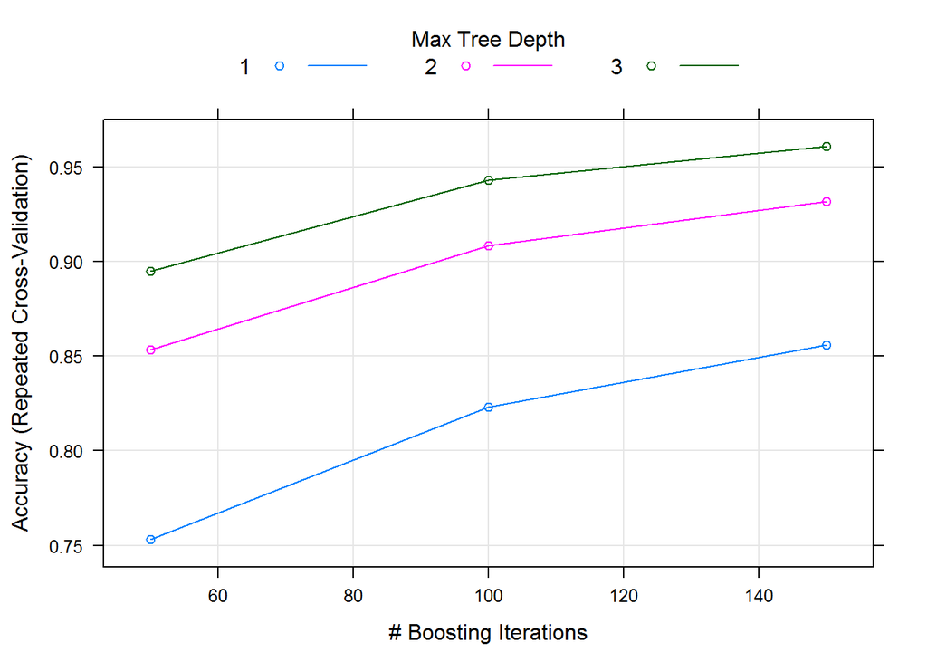

```r
plot(fit)
```